# Estudio sobre la fuga de clientes en una compañía telefónica

Hassan Chafi Xavier

28/1/2022

## Preparación de las herramientas de trabajo.

Lo primero que se debe comenzar haciendo es fijar el directorio de trabajo de nuestra máquina local de donde se cargarán las funciones que se harán uso así como instalar/cargar las librerías de R que se utilizarán.

```r
# Fijar el directorio de trabajo
setwd("C:/Users/96has/Documents/NTIC/6. Documentación minería de Datos y Modelización Predictiva-20211212")

# Cargar las funciones
source("Funciones_R.R")

# Instalar/cargar las librerías de R
paquetes(c("questionr", "psych", "car", "corrplot", "ggplot2", "gridExtra", "kableExtra", "dplyr", "DMwR2"))
```

## Lectura e inspección de datos. Tipo de variables, distribuciones, valores extraños, etc.

Esta primera fase constará de la lectura del archivo de datos y su inspección para observar los tipos de variables, las distribuciones que tienen las variables y determinar la presencia de valores outliers y missings.

```r
# Lectura del archivo de datos.
datos <- readRDS("C:/Users/96has/Documents/NTIC/6. Documentación minería de Datos y Modelización Predictiva-20211212/Tarea/FugaClientes_Training.RDS")
```

```r
# Observamos los detalles de las variables
str(datos)
```

```
## 'data.frame':    6353 obs. of  21 variables:
##  $ ID             : Factor w/ 6353 levels "0002-ORFBO","0003-MKNFE",..: 4858 3587 2338 4997 5879 5915 911 4316 5063 4102 ...
##  $ Genero         : Factor w/ 2 levels "Female","Male": 1 2 2 NA 1 1 2 1 NA 2 ...
##  $ Mayor65        : Factor w/ 2 levels "0","1": 1 1 1 1 1 1 1 1 1 1 ...
##  $ Conyuge        : Factor w/ 2 levels "No","Yes": 2 1 1 1 1 1 1 1 2 1 ...
##  $ PersCargo      : Factor w/ 2 levels "No","Yes": 1 1 1 1 1 1 2 1 1 2 ...
##  $ Antig.fc.edad  : num  1 34 2 45 NA 8 22 10 28 62 ...
##  $ Telf_serv      : Factor w/ 2 levels "No","Yes": 1 2 2 1 2 2 2 1 2 2 ...
##  $ VariasLineas   : Factor w/ 2 levels "No","Yes": 1 1 1 1 1 2 2 1 2 1 ...
##  $ Int_serv       : Factor w/ 3 levels "DSL","Fiber optic",..: 1 1 1 1 2 2 2 NA 2 1 ...
##  $ Seguridad      : Factor w/ 2 levels "No","Yes": 1 2 2 2 1 1 1 2 1 2 ...
##  $ CopiaSeguridad : Factor w/ 2 levels "No","Yes": 2 1 2 1 1 1 2 1 1 2 ...
##  $ Antivirus_disp : Factor w/ 2 levels "No","Yes": 1 2 1 2 1 2 1 1 2 1 ...
##  $ Soporte_tecnico: Factor w/ 2 levels "No","Yes": 1 1 1 2 1 1 1 1 2 1 ...
##  $ TV_streaming   : Factor w/ 2 levels "No","Yes": 1 1 1 1 1 2 2 1 2 1 ...
##  $ Peliculas      : Factor w/ 2 levels "No","Yes": 1 1 1 1 1 2 1 1 2 1 ...
##  $ Contrato       : Factor w/ 3 levels "Month-to-month",..: 1 2 1 2 1 1 1 1 1 NA ...
##  $ Fact_sinPapel  : Factor w/ 2 levels "No","Yes": 2 1 2 1 2 2 2 1 2 1 ...
##  $ MetodoPago     : Factor w/ 4 levels "Bank transfer (automatic)",..: NA 4 4 NA 3 NA 2 4 3 NA ...
##  $ FacturaMes     : num  NA NA 53.9 42.3 70.7 ...
##  $ FacturaTotal   : num  29.9 1889.5 108.2 1840.8 151.7 ...
##  $ Fuga           : Factor w/ 2 levels "0","1": 1 1 2 1 2 2 1 1 2 1 ...
```

Lo primero que se observa en este punto es que la variable ID está considerada como un factor, un aspecto que se ha de solucionar puesto que es una variable que no aporta valor en el modelado de los datos. También se va a proceder a recodificar las variables dicotómicas que adoptan los valores ‘Yes’/‘No’ por dos valores numéricos que representen estos valores anteriores.

Profundizando en las variables del archivo de datos se puede apreciar la distribución que tienen los valores de las variables donde, en cuanto a las variables continuas, ya se puede comenzar a sospechar de la presencia de valores extraños, entendiendo por ‘extraños’ la presencia de valores atípicos o outliers.

```r
# Observamos a detalle los valores de las variables
summary(datos)
```

```
##           ID          Genero     Mayor65     Conyuge    PersCargo
##  0002-ORFBO:   1   Female:2963   0   :5045   No :3287   No :4439
##  0003-MKNFE:   1   Male  :3038   1   : 956   Yes:3066   Yes:1914
##  0004-TLHLJ:   1   NA's  : 352   NA's: 352
##  0011-IGKFF:   1
##  0013-EXCHZ:   1
##  0013-MHZWF:   1
##  (Other)   :6347
##  Antig.fc.edad   Telf_serv   VariasLineas        Int_serv    Seguridad
##  Min.   : 0.00   No  : 605   No :3687     DSL        :2122   No :4532
##  1st Qu.: 9.00   Yes :5656   Yes:2666     Fiber optic:2702   Yes:1821
##  Median :29.00   NA's:  92                No         :1339
##  Mean   :32.38                            NA's       : 190
##  3rd Qu.:55.00
##  Max.   :72.00
##  NA's   :394
##  CopiaSeguridad Antivirus_disp Soporte_tecnico TV_streaming Peliculas
##  No :4180       No :4180       No :4509        No :3936     No :3902
##  Yes:2173       Yes:2173       Yes:1844        Yes:2417     Yes:2451
##
##
##
##
##
##            Contrato    Fact_sinPapel                     MetodoPago
##  Month-to-month:3285   No  :2483     Bank transfer (automatic):1283
##  One year      :1261   Yes :3609     Credit card (automatic)  :1290
##  Two year      :1413   NA's: 261     Electronic check         :1972
##  NA's          : 394                 Mailed check             :1336
##                                      NA's                     : 472
##
##
##    FacturaMes      FacturaTotal    Fuga
##  Min.   : 18.25   Min.   :  18.8   0:4667
##  1st Qu.: 35.55   1st Qu.: 394.5   1:1686
##  Median : 70.30   Median :1384.2
##  Mean   : 64.68   Mean   :2268.7
##  3rd Qu.: 89.80   3rd Qu.:3781.5
##  Max.   :118.75   Max.   :8672.5
##  NA's   :394      NA's   :11
```

El caso de la variable **FacturaTotal** llama la atención puesto que los valores de su media y su mediana son muy distantes entre si siendo la media muy superior a la mediana; esto hace sospechar de la presencia de outliers ya que pueden existir valores muy a la derecha que hagan este efecto de arrastre de la media hacia la derecha adoptando este valor tan elevado y superior a la mediana.

La representación gráfica de la variable **FacturaTotal** ayuda a conocer más en detalle su distribución pudiendo detectar la presencia de estos outliers.

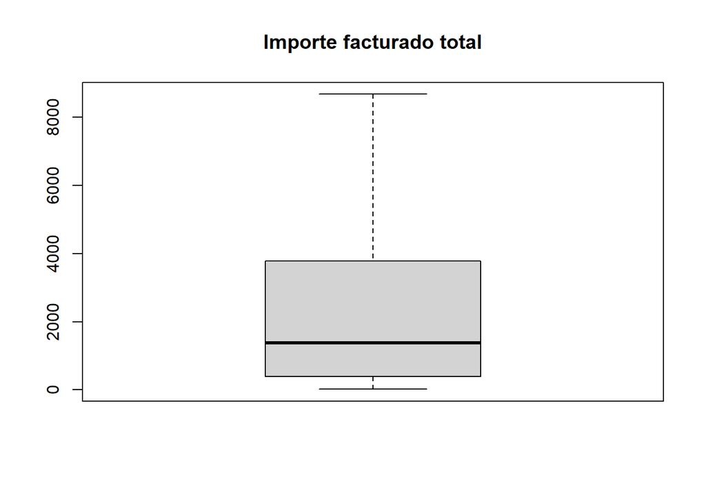

```r
# Boxplot variable FacturaTotal
boxplot(datos$FacturaTotal, main = "Importe facturado total")
```

Tras la representación del boxplot de la variable **FacturaTotal** se puede observar que no se aprecian outliers en la variable.

En cuanto a las variables numéricas que pudieran ser consideradas como categóricas, se considerarán numéricas si tienen más de diez valores distintos, con el objetivo de no consumir excesivamente números de parámetros del modelo.

```r
# Observamos los valores distintos que tienen las variables numéricas del archivo de datos
sapply(Filter(is.numeric, datos), FUN = function(x) length(unique(x)))
```

```
## Antig.fc.edad    FacturaMes  FacturaTotal
##            74          1523          5924
```

Se puede confirmar la presencia de missings en el archivo de datos mediante la siguiente consulta para la cual se devuelve un valor booleano TRUE que indica la presencia de dichos valores en las variables.

```r
# Consulta de la existencia de missings en el archivo de datos
any(is.na(datos))
```

```
## [1] TRUE
```

## Corrección de errores detectados.

Los errores que se han detectado hasta este punto y que se va a proceder a su corrección son:

- La variable **ID** que está considerada como un factor, se cambiará a un tipo de variable character para que no dé problemas a la hora de trabajar con las variables consideradas como factor y que aportan verdadero valor al modelo.
- A las variables **Conyuge**, **PersCargo**, **Telf_serv**, **VariasLineas**, **Seguridad**, **CopiaSeguridad**, **Antivirus_disp**, **Soporte_tecnico**, **TV_streaming**, **Peliculas** y **Fact_sinPapel** que son variables dicotómicas que adoptan los valores ‘Yes’/‘No’ se representará los valores ‘Yes’ por un 1 y los valores ‘No’ por un 0

```r
# Modificación del tipo de variable de ID
datos$ID <- as.character(datos$ID)
```

```r
#Recodificación de los valores de las variables dicotómicas
datos$Conyuge <- car::recode(datos$Conyuge, "'Yes' = 1; 'No' = 0", as.factor = TRUE)
datos$PersCargo <- car::recode(datos$PersCargo, "'Yes' = 1; 'No' = 0", as.factor = TRUE)
datos$Telf_serv <- car::recode(datos$Telf_serv, "'Yes' = 1; 'No' = 0", as.factor = TRUE)
datos$VariasLineas <- car::recode(datos$VariasLineas, "'Yes' = 1; 'No' = 0", as.factor = TRUE)
datos$Seguridad <- car::recode(datos$Seguridad, "'Yes' = 1; 'No' = 0", as.factor = TRUE)
datos$CopiaSeguridad <- car::recode(datos$CopiaSeguridad, "'Yes' = 1; 'No' = 0", as.factor = TRUE)
datos$Antivirus_disp <- car::recode(datos$Antivirus_disp, "'Yes' = 1; 'No' = 0", as.factor = TRUE)
datos$Soporte_tecnico <- car::recode(datos$Soporte_tecnico, "'Yes' = 1; 'No' = 0", as.factor = TRUE)
datos$TV_streaming <- car::recode(datos$TV_streaming, "'Yes' = 1; 'No' = 0", as.factor = TRUE)
datos$Peliculas <- car::recode(datos$Peliculas, "'Yes' = 1; 'No' = 0", as.factor = TRUE)
datos$Fact_sinPapel <- car::recode(datos$Fact_sinPapel, "'Yes' = 1; 'No' = 0", as.factor = TRUE)
```

Voy a comprobar la frecuencia de aparición de los valores de las variables categóricas para realizar una reflexión de si se debería unificar categorías dentro de estas variables.

```r
# Comprobación de la frecuencia de aparición de los valores de las variables categóricas
lapply(Filter(is.factor, datos), FUN = freq)
```

```
## $Genero
##           n    % val%
## Female 2963 46.6 49.4
## Male   3038 47.8 50.6
## NA      352  5.5   NA
##
## $Mayor65
##       n    % val%
## 0  5045 79.4 84.1
## 1   956 15.0 15.9
## NA  352  5.5   NA
##
## $Conyuge
##      n    % val%
## 0 3287 51.7 51.7
## 1 3066 48.3 48.3
##
## $PersCargo
##      n    % val%
## 0 4439 69.9 69.9
## 1 1914 30.1 30.1
##
## $Telf_serv
##       n    % val%
## 0   605  9.5  9.7
## 1  5656 89.0 90.3
## NA   92  1.4   NA
##
## $VariasLineas
##      n  % val%
## 0 3687 58   58
## 1 2666 42   42
##
## $Int_serv
##                n    % val%
## DSL         2122 33.4 34.4
## Fiber optic 2702 42.5 43.8
## No          1339 21.1 21.7
## NA           190  3.0   NA
##
```

[output cut: 40 more lines]

```
## 1  3609 56.8 59.2
## NA  261  4.1   NA
##
## $MetodoPago
##                              n    % val%
## Bank transfer (automatic) 1283 20.2 21.8
## Credit card (automatic)   1290 20.3 21.9
## Electronic check          1972 31.0 33.5
## Mailed check              1336 21.0 22.7
## NA                         472  7.4   NA
##
## $Fuga
##      n    % val%
## 0 4667 73.5 73.5
## 1 1686 26.5 26.5
```

Como se ha podido observar, algunas variables que se podrían haber modificado como **Int_serv**, **Contrato** y **MetodoPago** tienen unos valores muy representativos, todos superiores al 20% en cuanto a representación, por lo que podemos considerar conveniente mantener estas variables como vienen definidas para que sus valores no adopten un carácter genérico.

Antes de ello, se observa los detalles de las variables del archivo de datos para comprobar que las modificaciones se han realizado correctamente y que no existan variables categóricas con valores poco representados.

```r
# Observamos los detalles de las columnas del archivo de datos
str(datos)
```

```
## 'data.frame':    6353 obs. of  21 variables:
##  $ ID             : chr  "7590-VHVEG" "5575-GNVDE" "3668-QPYBK" "7795-CFOCW" ...
##  $ Genero         : Factor w/ 2 levels "Female","Male": 1 2 2 NA 1 1 2 1 NA 2 ...
##  $ Mayor65        : Factor w/ 2 levels "0","1": 1 1 1 1 1 1 1 1 1 1 ...
##  $ Conyuge        : Factor w/ 2 levels "0","1": 2 1 1 1 1 1 1 1 2 1 ...
##  $ PersCargo      : Factor w/ 2 levels "0","1": 1 1 1 1 1 1 2 1 1 2 ...
##  $ Antig.fc.edad  : num  1 34 2 45 NA 8 22 10 28 62 ...
##  $ Telf_serv      : Factor w/ 2 levels "0","1": 1 2 2 1 2 2 2 1 2 2 ...
##  $ VariasLineas   : Factor w/ 2 levels "0","1": 1 1 1 1 1 2 2 1 2 1 ...
##  $ Int_serv       : Factor w/ 3 levels "DSL","Fiber optic",..: 1 1 1 1 2 2 2 NA 2 1 ...
##  $ Seguridad      : Factor w/ 2 levels "0","1": 1 2 2 2 1 1 1 2 1 2 ...
##  $ CopiaSeguridad : Factor w/ 2 levels "0","1": 2 1 2 1 1 1 2 1 1 2 ...
##  $ Antivirus_disp : Factor w/ 2 levels "0","1": 1 2 1 2 1 2 1 1 2 1 ...
##  $ Soporte_tecnico: Factor w/ 2 levels "0","1": 1 1 1 2 1 1 1 1 2 1 ...
##  $ TV_streaming   : Factor w/ 2 levels "0","1": 1 1 1 1 1 2 2 1 2 1 ...
##  $ Peliculas      : Factor w/ 2 levels "0","1": 1 1 1 1 1 2 1 1 2 1 ...
##  $ Contrato       : Factor w/ 3 levels "Month-to-month",..: 1 2 1 2 1 1 1 1 1 NA ...
##  $ Fact_sinPapel  : Factor w/ 2 levels "0","1": 2 1 2 1 2 2 2 1 2 1 ...
##  $ MetodoPago     : Factor w/ 4 levels "Bank transfer (automatic)",..: NA 4 4 NA 3 NA 2 4 3 NA ...
##  $ FacturaMes     : num  NA NA 53.9 42.3 70.7 ...
##  $ FacturaTotal   : num  29.9 1889.5 108.2 1840.8 151.7 ...
##  $ Fuga           : Factor w/ 2 levels "0","1": 1 1 2 1 2 2 1 1 2 1 ...
```

## Tratamiento de outliers.

Para comenzar a tratar los outliers y, posteriormente los missings, se separarán las variables predictoras de la variable objetivo.

```r
# Creación del DataFrame de variables predictoras
varID <- datos$ID
varObj <- datos$Fuga
input <- as.data.frame(datos[ , -c(1, 21)]) # Descarto la variable ID y la variable objetivo
```

Una buena forma de seguir profundizando en la observación de la distribución de las variables continuas tras haberlas graficado en un boxplot y haber observado su media y mediana; es ver los valores que tienen la curtosis y la asimetría para dichas variables. De esta manera, llama la atención que la variable ‘FacturaTotal’ tenga un valor tan elevado en cuanto a su asimetría, es decir, su cola a la derecha es más larga que en la izquierda e indica valores positivos muy alejados de la media. Esto es una fuerte sospecha de la posible presencia de outliers en dicha variable pero no podemos asegurar realmente su existencia, por ello se va a valorar la incidencia de outliers por cada variable continua predictora.

```r
psych::describe(Filter(is.numeric, input))
```

```
##               vars    n    mean      sd  median trimmed     mad   min     max
## Antig.fc.edad    1 5959   32.38   24.54   29.00   31.44   32.62  0.00   72.00
## FacturaMes       2 5959   64.68   30.01   70.30   64.87   35.58 18.25  118.75
## FacturaTotal     3 6342 2268.73 2258.84 1384.17 1954.72 1801.28 18.80 8672.45
##                 range  skew kurtosis    se
## Antig.fc.edad   72.00  0.24    -1.39  0.32
## FacturaMes     100.50 -0.22    -1.25  0.39
## FacturaTotal  8653.65  0.97    -0.22 28.36
```

Mediante el criterio seguido para determinar la presencia de outliers (criterio 3 sd + criterio de 3 IQR en las variables con distribuciones simétricas y el criterio del MAD con valor 8 + criterio de 3 IQR en las variables con distribuciones asimétricas), no se detecta presencia de ningún valor atípico en las variables continuas del dataframe de variables predictoras.

```r
# Tabla con porcentaje de outliers por variable
outliersV <- data.frame(sort(
  round(sapply(Filter(
    is.numeric, input), function(nOut) atipicosAmissing(
      nOut)[[2]]) / nrow(input) * 100, 3), decreasing = TRUE))
names(outliersV) <- "% Outliers por variable"
outliersV
```

```
##               % Outliers por variable
## Antig.fc.edad                       0
## FacturaMes                          0
## FacturaTotal                        0
```

## Tratamiento de missings.

Empezar a analizar los valores missings de las variables requiere inicialmente conocer la existencia de patrones de coexistencia entre las distintas variables. La presencia de un patrón de coexistencia de missings entre dos variables querría decir que los registros del archivo de datos que tienen missings en una variable, lo tienden a tener también en la otra variable para la que existe dicho patrón de coexistencia. En el caso de este estudio, el diagrama indica que no existen patrones entre las variables por lo que podemos pasar a cuantificar el porcentaje de missings por cada una de las variables y considerar un criterio adecuado para su tratamiento.

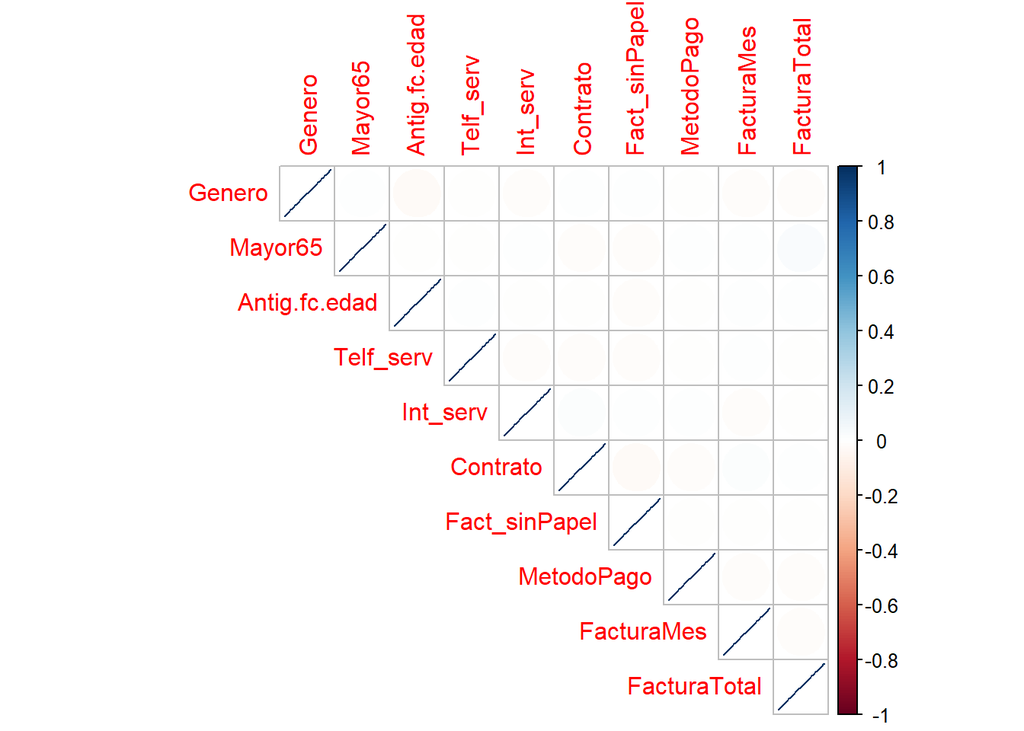

```r
corrplot(cor(is.na(input[colnames(input)[colSums(is.na(input)) > 0]])),method = "ellipse",type = "upper")
```

```r
prop_missingsV <- apply(is.na(input), 2, mean)

# Tabla con porcentaje de missings por variable
missingsV <- data.frame(sort(prop_missingsV * 100, decreasing = TRUE))
names(missingsV) <- "% Missings por Variable"
missingsV
```

```
##                 % Missings por Variable
## MetodoPago                    7.4295608
## Antig.fc.edad                 6.2017944
## Contrato                      6.2017944
## FacturaMes                    6.2017944
## Genero                        5.5406894
## Mayor65                       5.5406894
## Fact_sinPapel                 4.1082953
## Int_serv                      2.9907130
## Telf_serv                     1.4481347
## FacturaTotal                  0.1731465
## Conyuge                       0.0000000
## PersCargo                     0.0000000
## VariasLineas                  0.0000000
## Seguridad                     0.0000000
## CopiaSeguridad                0.0000000
## Antivirus_disp                0.0000000
## Soporte_tecnico               0.0000000
## TV_streaming                  0.0000000
## Peliculas                     0.0000000
```

Se procede a la imputación de los valores missings en las variables cuantitativas con el valor de la media de sus valores y las variables cualitativas con la moda.

```r
# Imputación de las variables cuantitativas
input[ ,as.vector(which(sapply(input, class) == "numeric"))] <- sapply(Filter(is.numeric, input),
                                                                       function(x) ImputacionCuant(x, "media"))

# Inputación de las variables cualitativas
input[ ,as.vector(which(sapply(input, class) == "factor"))] <- sapply(Filter(is.factor, input),
                                                                      function(x) ImputacionCuali(x, "moda"))
```

```r
# Las variables categóricas han pasado a ser de tipo character y hay que indicarle nuevamente que son de tipo factor
input[, as.vector(which(sapply(input, class) == "character"))] <- lapply(input[ ,as.vector(which(sapply(input, class) == "character"))] , factor)
```

```r
summary(input)
```

```
##     Genero     Mayor65  Conyuge  PersCargo Antig.fc.edad   Telf_serv
##  Female:2963   0:5397   0:3287   0:4439    Min.   : 0.00   0: 605
##  Male  :3390   1: 956   1:3066   1:1914    1st Qu.:10.00   1:5748
##                                            Median :32.00
##                                            Mean   :32.38
##                                            3rd Qu.:54.00
##                                            Max.   :72.00
##  VariasLineas        Int_serv    Seguridad CopiaSeguridad Antivirus_disp
##  0:3687       DSL        :2122   0:4532    0:4180         0:4180
##  1:2666       Fiber optic:2892   1:1821    1:2173         1:2173
##               No         :1339
##
##
##
##  Soporte_tecnico TV_streaming Peliculas           Contrato    Fact_sinPapel
##  0:4509          0:3936       0:3902    Month-to-month:3679   0:2483
##  1:1844          1:2417       1:2451    One year      :1261   1:3870
##                                         Two year      :1413
##
##
##
##                      MetodoPago     FacturaMes      FacturaTotal
##  Bank transfer (automatic):1283   Min.   : 18.25   Min.   :  18.8
##  Credit card (automatic)  :1290   1st Qu.: 41.10   1st Qu.: 396.3
##  Electronic check         :2444   Median : 68.75   Median :1387.3
##  Mailed check             :1336   Mean   : 64.68   Mean   :2268.7
##                                   3rd Qu.: 89.00   3rd Qu.:3778.0
##                                   Max.   :118.75   Max.   :8672.5
```

```r
# Aplico de nuevo la función para los missings
if (any(is.na(input))){
  input[ ,as.vector(which(sapply(input, class) == "numeric"))] <- sapply(
  Filter(is.numeric, input), function(x) ImputacionCuant(x, "aleatorio"))

# Reviso que no queden missings
summary(input)
}
```

De esta manera, ya se puede afirmar que los datos se han depurado correctamente. Se puede hacer una inspección gráfica final para su visualización.

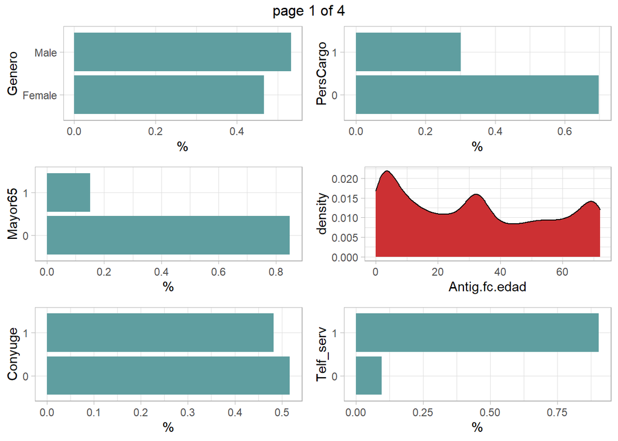

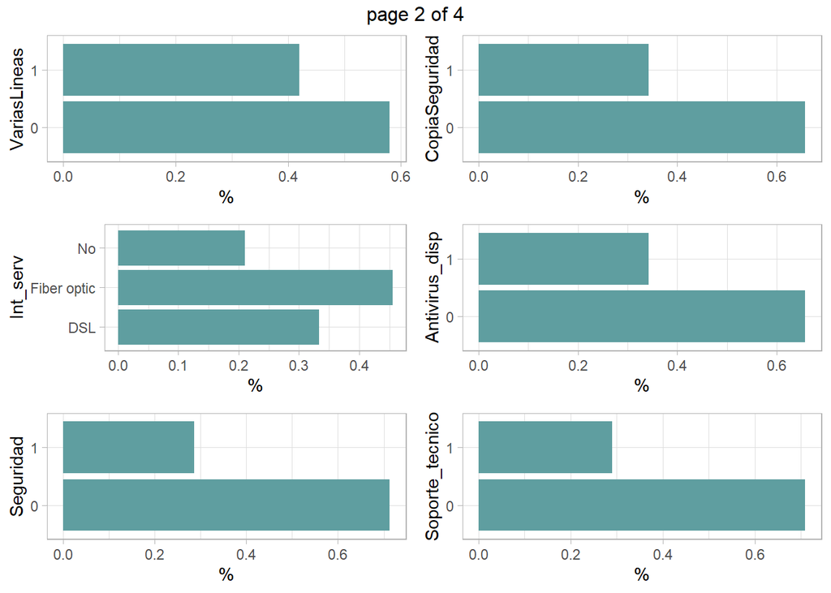

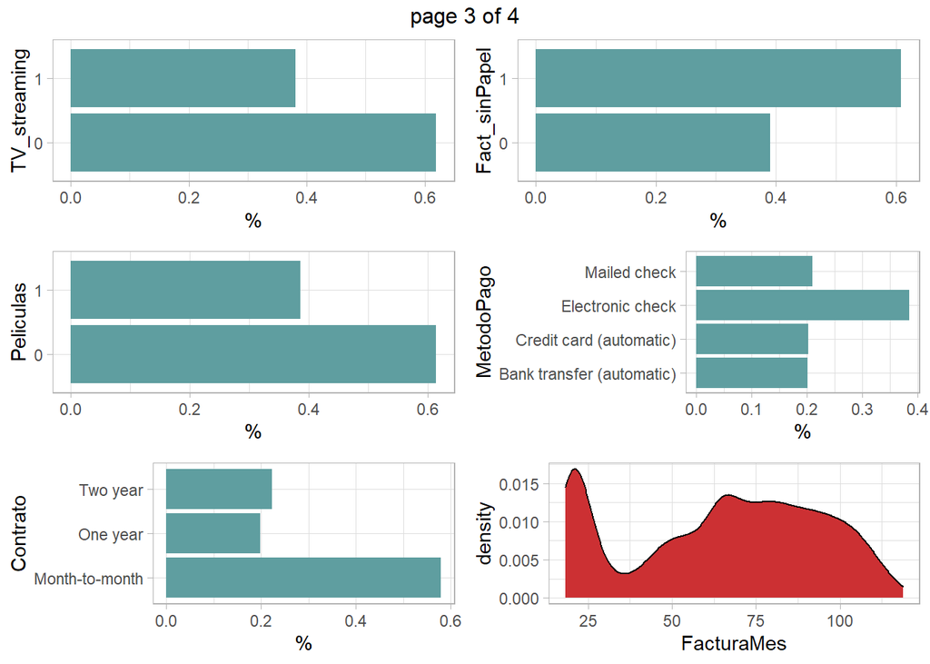

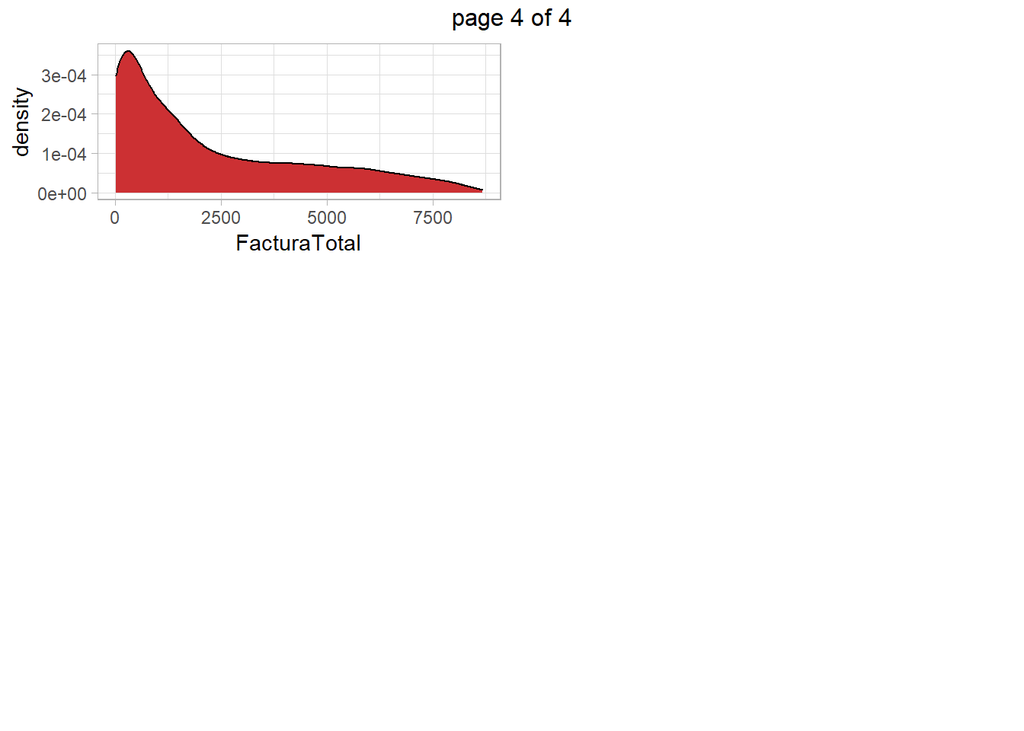

```r
# Graficar el Dataset
par(mfrow = c(3,3))
lista_his <- dfplot_his(input)
gridExtra::marrangeGrob(lista_his, nrow=3, ncol=2)
```

Se puede afirmar que el proceso que involucra la depuración de los datos se ha finalizado adecuadamente por lo que a continuación se puede proceder a su almacenamiento.

```r
# Se guardan los datos
saveRDS(cbind(varObj, input),"datosTelefoniaDep.RDS")
```